# Topic 27

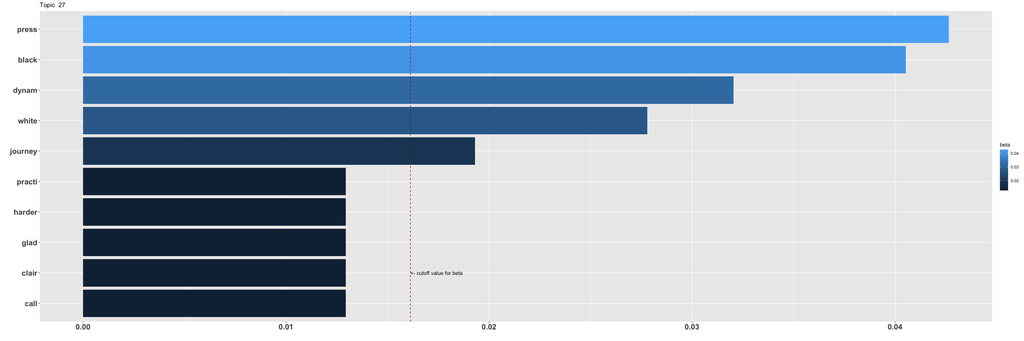

On interpreting beta: the term has a beta probability of being generated from the particular topic.

Values below are gamma : An estimated proportion of words from that document that are generated from that topic.

**Text Record Number: 1271** gamma: 15 % likelihood of this document (based on its words) in this topic

**Hello, I’m new here and I don’t understand one thing, while I’m trying to play a piece and sometimes when there is an accidentals on the sheet of music I play the correct key, but sometimes it happens that a white key has to be pressed on the sheet of music, even though it is more likely the black is sometimes I also watch videos where the pieces are played and the black keys are played I am currently trying Clair de Lune and I am very confused about the black keys which characters still point to a black key?**

**Text Record Number: 1380** gamma: 15 % likelihood of this document (based on its words) in this topic

**So I kept telling about my problem at looking at my hands while playing but then you guys said it’s a good idea to cover hands while playing. But i keep feeling the black keys to feel the white ones and feel the white keys. Is it okay to feel the black ones even though I am beginner and it takes about slow for me to play the song. If you don’t get the thing I said please say so I’ll go in detail**

**Text Record Number: 1387** gamma: 15 % likelihood of this document (based on its words) in this topic

**So I kept telling about my problem at looking at my hands while playing but then you guys said it’s a good idea to cover hands while playing. But i keep feeling the black keys to feel the white ones and feel the white keys. Is it okay to feel the black ones even though I am beginner and it takes about slow for me to play the song. If you don’t get the thing I said please say so I’ll go in detail.**

**Text Record Number: 1320** gamma: 15 % likelihood of this document (based on its words) in this topic

**Hello!

Basically, I know that when learning fast passages, it’s best to play the passage hands separately first (very slowly and loudly to build muscle memory), then to practice the passage repeatedly with gradual increases in the tempo, and then eventually together.

However, I have some questions about this process:

1. If both the left hand and right hand have difficult, fast passages, which of these is the more effective way of progressing to play hands together? (If you have your own method which you’d like to share, please feel free to do so :D)
1. Should I practice each hand separately from a slow tempo to the actual intended tempo, and then only after I can play at the intended tempo with each hand, start playing the passage with both hands (at a slower tempo, then faster again)?
2. Or should I complete the passage in sections, by practicing hands separately then hands together in tempo intervals? E.g. If the slow tempo is 60bpm and the intended tempo is 100bpm, then I could practice each hand separately from 60 to 70bpm, then hands together from 60 to 70bpm; then hands separately to 80bpm, then hands together to 80bpm, etc.
2. How hard should I be pressing the keys as I get better and more practiced at a fast passage? Because, I know that when initially learning a fast passage, it’s beneficial to play very slowly and loudly, and press the keys hard (but still with correct technique and not in a harmful way) to develop muscle memory. However, at what point is it fine for me to stop pressing so hard, so that my finger speed can increase? Because pressing each finger hard into each key adds extra stiffness to my fingers, especially when I start to increase the tempo more and more, which will slow down the speed at which I can play the notes (and most of the time the fast passage won’t actually need to be played with such loud notes, unless the dynamic is forte or fortissimo).

If you can help me with any of the questions which I’ve asked, I’d really appreciate it a lot :)

Thank you in advance!**

**Text Record Number: 912** gamma: 15 % likelihood of this document (based on its words) in this topic

**If you were desperate, as in a teen buying a battery and a kitkat foil wrapper to light a joint. You could turn off the sound and listen to just the dynamics from you physically pressing the keys harder.

Otherwise, best to save for a decent keyboard/piano. It is a much easier skill than others to pick up, but you do need the audio feedback to be able to tell how loud the notes are from the pressure you use to press them.

Tbh it’s simple enough that if you learn pretty much three levels of f/p (basic loud/quiet) , mf/mp(slight steps louder/quieter) , fff/ppp(extremes of pressure), then being able to independently and simultaneously do that for multiple melodies (that bit’s hard actually) is basically it for most pieces. The hardest and professional level of dynamic control is honestly so subtle sometimes that for most pianists and pieces it doesn’t matter.

You won’t really be hindered in that you’ll develop bad habits, but you will need some practice at some point to be able to represent dynamics.

As others have said, if you get something that can detect pressure change, and has two/three pedals, you can physically practice most anything. Extra stuff is quality improvement.**

**Text Record Number: 1057** gamma: 15 % likelihood of this document (based on its words) in this topic

**Here’s how I did it, but I just kinda came to this system by myself so am not sure if it’s the right way, still, maybe it’ll help you. I do practice the hands separately first, then when I can remember the placements and fingerings well enough, I start playing then together. So how I do that is I’ll look at the sheet music then go note by note. If it’s purely played with the left hand then just play that one note, if it’s played together, then press both notes together, or however many notes are pressed together, on both hands. Sometimes I may just look at my fingerings again to make sure they’re right before I press them. This might take quite long for you if you’re not used to it but slowly you’ll start to feel like playing both hands together feels okay and familiar and then you should be able to get the hang of it.**

**Text Record Number: 965** gamma: 15 % likelihood of this document (based on its words) in this topic

**Practise drills that test the ability to do different things with each hand, or improvise over a simple bass line**